# Homework 2

PSTAT 131/231 - Gabrielle Salo

## Linear Regression

For this lab, we will be working with a data set from the UCI (University of California, Irvine) Machine Learning repository ([see website here](http://archive.ics.uci.edu/ml/datasets/Abalone)). The full data set consists of $4,177$ observations of abalone in Tasmania. (Fun fact: Tasmania supplies about $25\%$ of the yearly world abalone harvest.)

The age of an abalone is typically determined by cutting the shell open and counting the number of rings with a microscope. The purpose of this data set is to determine whether abalone age (**number of rings + 1.5**) can be accurately predicted using other, easier-to-obtain information about the abalone.

The full abalone data set is located in the `\data` subdirectory. Read it into *R* using `read_csv()`. Take a moment to read through the codebook (`abalone_codebook.txt`) and familiarize yourself with the variable definitions.

Make sure you load the `tidyverse` and `tidymodels`!

```r
library(MASS)
library(ggplot2)
library(tidyverse)
library(corrr)
library(tidymodels)
library(corrplot)
library(ggthemes)
library(dplyr)
knitr::opts_chunk$set(echo=T,
                      eval=T,
                      cache=T,
                      results='markup',
                      message=F,
                      warning=F,
                      fig.height=6,
                      fig.width=6,
                      fig.align='center')
```

```r
data <- read.csv("C:/Users/gabri/Desktop/Desktop New/Desktop/PHD PROGRAM/2022 Q4 Fall Work/PStat 231/Labs/PStat231/abalone.csv", header=TRUE, sep=",")
data <- data.frame(data)
glimpse(data)
```

```
## Rows: 4,177
## Columns: 9
## $ Sex            <chr> "M", "M", "F", "M", "I", "I", "F", "F", "M", "F", "F", …
## $ Length         <dbl> 0.455, 0.350, 0.530, 0.440, 0.330, 0.425, 0.530, 0.545,…
## $ Diameter       <dbl> 0.365, 0.265, 0.420, 0.365, 0.255, 0.300, 0.415, 0.425,…
## $ Height         <dbl> 0.095, 0.090, 0.135, 0.125, 0.080, 0.095, 0.150, 0.125,…
## $ Whole_weight   <dbl> 0.5140, 0.2255, 0.6770, 0.5160, 0.2050, 0.3515, 0.7775,…
## $ Shucked_weight <dbl> 0.2245, 0.0995, 0.2565, 0.2155, 0.0895, 0.1410, 0.2370,…
## $ Viscera_weight <dbl> 0.1010, 0.0485, 0.1415, 0.1140, 0.0395, 0.0775, 0.1415,…
## $ Shell_weight   <dbl> 0.150, 0.070, 0.210, 0.155, 0.055, 0.120, 0.330, 0.260,…
## $ Rings          <int> 15, 7, 9, 10, 7, 8, 20, 16, 9, 19, 14, 10, 11, 10, 10, …
```

### Question 1

Your goal is to predict abalone age, which is calculated as the number of rings plus 1.5. Notice there currently is no `age` variable in the data set. Add `age` to the data set.

Assess and describe the distribution of `age`.

```r
data$Age <- data$Rings+1.5
head(data)
```

```
##   Sex Length Diameter Height Whole_weight Shucked_weight Viscera_weight
## 1   M  0.455    0.365  0.095       0.5140         0.2245         0.1010
## 2   M  0.350    0.265  0.090       0.2255         0.0995         0.0485
## 3   F  0.530    0.420  0.135       0.6770         0.2565         0.1415
## 4   M  0.440    0.365  0.125       0.5160         0.2155         0.1140
## 5   I  0.330    0.255  0.080       0.2050         0.0895         0.0395
## 6   I  0.425    0.300  0.095       0.3515         0.1410         0.0775
##   Shell_weight Rings  Age
## 1        0.150    15 16.5
## 2        0.070     7  8.5
## 3        0.210     9 10.5
## 4        0.155    10 11.5
## 5        0.055     7  8.5
## 6        0.120     8  9.5
```

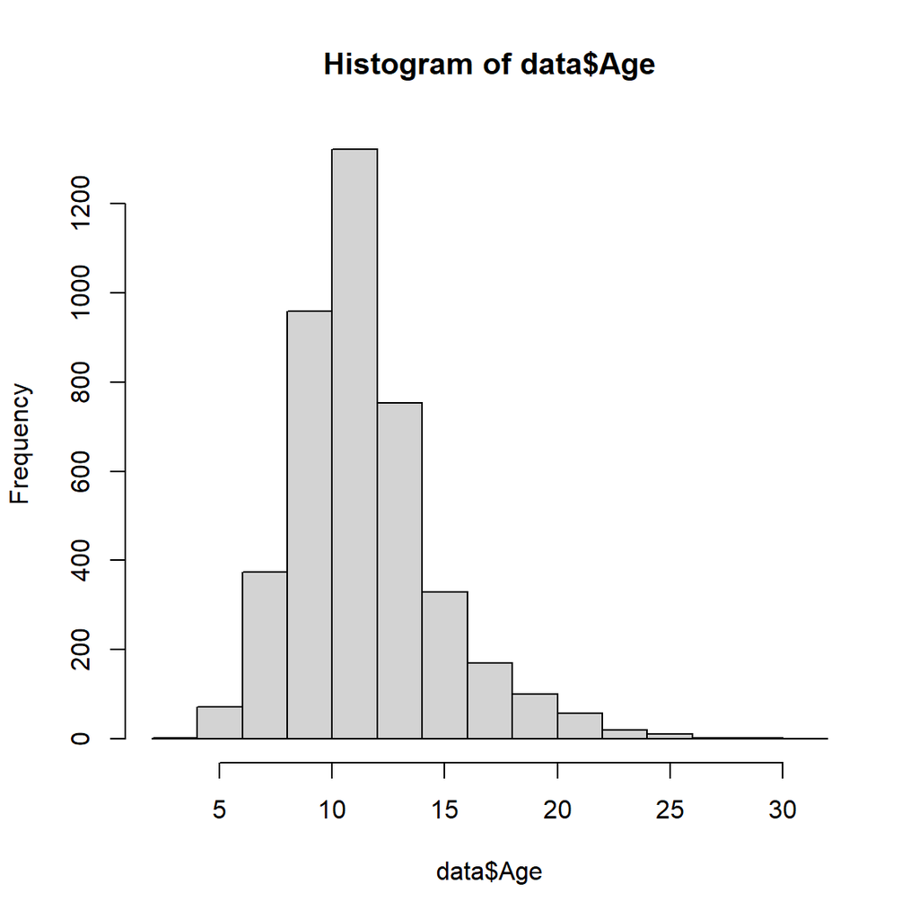

```r
hist(data$Age)
```

```r
mean(data$Age)
```

```
## [1] 11.43368
```

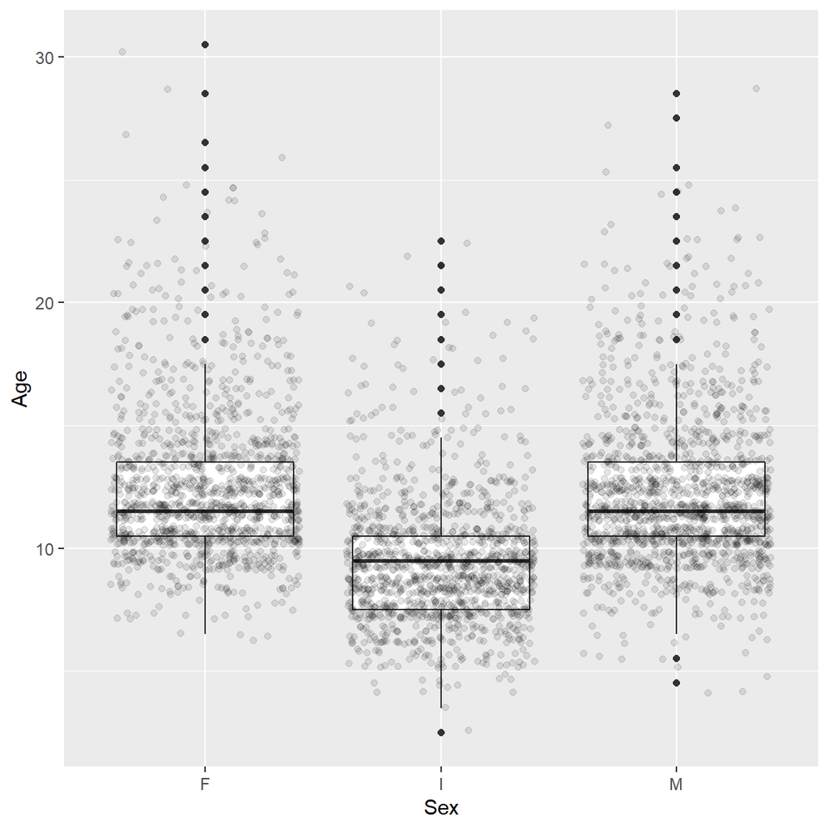

```r
#cor_ab %>%
#  stretch() %>%
#  ggplot(aes(x, y, fill = r)) +
#  geom_tile() +
#  geom_text(aes(label = as.character(fashion(r))))

ggplot(data, aes(factor(Sex), Age)) +
  geom_boxplot() +
  geom_jitter(alpha = 0.1) +
  xlab("Sex")
```

Per the data provided, the Average age of an abalone is 11.4 years. The plot looks to be poisson with lambda of 11.4.

### Question 2

Split the abalone data into a training set and a testing set. Use stratified sampling. You should decide on appropriate percentages for splitting the data.

*Remember that you’ll need to set a seed at the beginning of the document to reproduce your results.*

```r
set.seed(7)
dataog <- data
data2 <- subset(dataog, select = -c(Rings)) %>% na.omit
data1 <- data2 %>% filter(Sex == "M" | Sex =="F")
data1 <- subset(data1, select = -c(Sex))
ab_split <- initial_split(data1, prop = 0.80,
                                strata = Age,
                                breaks = 4)

#?initial_split
ab_train <- training(ab_split) #80% of the data
ab_test <- testing(ab_split)   #20% of the data

#hist(ab_train$Age)
#hist(ab_test$Age)
```

### Question 3

Using the **training** data, create a recipe predicting the outcome variable, `age`, with all other predictor variables. Note that you should not include `rings` to predict `age`. Explain why you shouldn’t use `rings` to predict `age`.

Steps for your recipe:

1. dummy code any categorical predictors
2. create interactions between
   - `type` and `shucked_weight`,
   - `longest_shell` and `diameter`,
   - `shucked_weight` and `shell_weight`
3. center all predictors, and
4. scale all predictors.

You’ll need to investigate the `tidymodels` documentation to find the appropriate step functions to use.

Answer: Rings is not appropriate to use when predicting age because Age and rings has a correlation of 1, because Age is Rings +1.5, a one to one line relationship.

```r
#glm(Age~.-Rings,family=poisson,data=data)
names(data1)
```

```
## [1] "Length"         "Diameter"       "Height"         "Whole_weight"
## [5] "Shucked_weight" "Viscera_weight" "Shell_weight"   "Age"
```

```r
rec <- recipe(Age~., data=ab_train)
#gen <- tribble(~sex_M, ~sex_F, ~sex_I, "M", "F", "I")

#dummy_multi_choice_rec <- recipe(~., data = gen) %>% step_dummy_multi_choice(starts_with("sex")) %>% prep()
#bake(dummy_multi_choice_rec, new_data = NULL)
#  step_dummy_multi_choice(all_nominal()) %>%


ab_recipe <- rec %>%
#  step_dummy(Sex) %>%
#  step_interact(terms = ~ starts_with(Sex):Shucked_weight) %>%
  step_interact(terms = ~ Length:Diameter) %>%
  step_interact(terms = ~ Shucked_weight:Shell_weight) %>%
  step_center(all_numeric_predictors()) %>%
  step_scale(all_numeric_predictors())

summary(ab_recipe)
```

```
## # A tibble: 8 × 4
##   variable       type    role      source
##   <chr>          <chr>   <chr>     <chr>
## 1 Length         numeric predictor original
## 2 Diameter       numeric predictor original
## 3 Height         numeric predictor original
## 4 Whole_weight   numeric predictor original
## 5 Shucked_weight numeric predictor original
## 6 Viscera_weight numeric predictor original
## 7 Shell_weight   numeric predictor original
## 8 Age            numeric outcome   original
```

### Question 4

Create and store a linear regression object using the `"lm"` engine.

```r
#ab_train <- training(ab_split) #80% of the data
#ab_test <- testing(ab_split)   #20% of the data

lm_model <- linear_reg() %>%
  set_engine("lm")
#lr_mod <- logistic_reg() %>% set_engine("glm")
```

### Question 5

Now:

1. set up an empty workflow,
2. add the model you created in Question 4, and
3. add the recipe that you created in Question 3.

```r
ab_workflow <- workflow() %>%
  add_model(lm_model) %>%
  add_recipe(ab_recipe)
```

### Question 6

Use your `fit()` object to predict the age of a hypothetical female abalone with longest_shell = 0.50, diameter = 0.10, height = 0.30, whole_weight = 4, shucked_weight = 1, viscera_weight = 2, shell_weight = 1.

Predicted Age is about 22.7.

```r
ab_workflow %>%
  fit(ab_train)
```

```
## ══ Workflow [trained] ══════════════════════════════════════════════════════════
## Preprocessor: Recipe
## Model: linear_reg()
##
## ── Preprocessor ────────────────────────────────────────────────────────────────
## 4 Recipe Steps
##
## • step_interact()
## • step_interact()
## • step_center()
## • step_scale()
##
## ── Model ───────────────────────────────────────────────────────────────────────
##
## Call:
## stats::lm(formula = ..y ~ ., data = data)
##
## Coefficients:
##                   (Intercept)                         Length
##                       12.4038                         0.8139
##                      Diameter                         Height
##                        2.2417                         0.1890
##                  Whole_weight                 Shucked_weight
##                        5.0325                        -4.4614
##                Viscera_weight                   Shell_weight
##                       -0.9957                         0.9091
##             Length_x_Diameter  Shucked_weight_x_Shell_weight
##                       -3.1456                         0.4113
```

```r
ab_fit <- ab_workflow %>%
  fit(data=ab_train)
```

```r
lm_model <- linear_reg() %>%
  set_engine("lm")

### Workflow

wkflow <- workflow() %>%
  add_model(lm_model) %>%
  add_recipe(ab_recipe)

fitab <- fit(wkflow, ab_train)

### Model Results

fitab %>%
  tidy()
```

```
## # A tibble: 10 × 5
##    term                          estimate std.error statistic  p.value
##    <chr>                            <dbl>     <dbl>     <dbl>    <dbl>
##  1 (Intercept)                     12.4      0.0499    248.   0
##  2 Length                           0.814    0.357       2.28 2.27e- 2
##  3 Diameter                         2.24     0.370       6.06 1.60e- 9
##  4 Height                           0.189    0.0721      2.62 8.84e- 3
##  5 Whole_weight                     5.03     0.437      11.5  6.67e-30
##  6 Shucked_weight                  -4.46     0.314     -14.2  5.80e-44
##  7 Viscera_weight                  -0.996    0.172      -5.79 8.13e- 9
##  8 Shell_weight                     0.909    0.263       3.46 5.47e- 4
##  9 Length_x_Diameter               -3.15     0.551      -5.71 1.30e- 8
## 10 Shucked_weight_x_Shell_weight    0.411    0.306       1.34 1.80e- 1
```

```r
new_obs = data.frame( Length = 0.50, Diameter = 0.10, Height = 0.30, Whole_weight = 4, Shucked_weight = 1, Viscera_weight = 2, Shell_weight = 1)

predict(ab_fit, new_data = new_obs)
```

```
## # A tibble: 1 × 1
##   .pred
##   <dbl>
## 1  22.7
```

### Question 7

Now you want to assess your model’s performance. To do this, use the `yardstick` package:

1. Create a metric set that includes *R<sup>2</sup>*, RMSE (root mean squared error), and MAE (mean absolute error).
2. Use `predict()` and `bind_cols()` to create a tibble of your model’s predicted values from the **training data** along with the actual observed ages (these are needed to assess your model’s performance).
3. Finally, apply your metric set to the tibble, report the results, and interpret the *R<sup>2</sup>* value.

```r
library(yardstick)
library(dplyr)

#1
(class_metrics <- metric_set(rmse, mae))
```

```
## # A tibble: 2 × 3
##   metric class          direction
##   <chr>  <chr>          <chr>
## 1 rmse   numeric_metric minimize
## 2 mae    numeric_metric minimize
```

```r
#2
new_obs = data.frame( Length = 0.50, Diameter = 0.10, Height = 0.30, Whole_weight = 4, Shucked_weight = 1, Viscera_weight = 2, Shell_weight = 1)

pAge <- predict(ab_fit, new_data = ab_test)

abpAge <- bind_cols(ab_test,pAge) %>%
  metrics(truth=Age, estimate=.pred)

#3
```

[output not shown]

### Required for 231 Students

In lecture, we presented the general bias-variance tradeoff, which takes the form:

$$E[(y_0 -
\hat{f}(x_0))^2]=Var(\hat{f}(x_0))+[Bias(\hat{f}(x_0))]^2+Var(\epsilon)$$

where the underlying model $Y=f(X)+\epsilon$ satisfies the following:

- $\epsilon$ is a zero-mean random noise term and $X$ is non-random (all randomness in $Y$ comes from $\epsilon$);
- $(x_0, y_0)$ represents a test observation, independent of the training set, drawn from the same model;
- $\hat{f}(.)$ is the estimate of $f$ obtained from the training set.

#### Question 8

Which term(s) in the bias-variance tradeoff above represent the reproducible error? Which term(s) represent the irreducible error?

$Var(\hat{f}(x_0))+[Bias(\hat{f}(x_0))]^2$

is the reproducible error

$Var(\epsilon)$ is the Irreducible Error

#### Question 9

Using the bias-variance tradeoff above, demonstrate that the expected test error is always at least as large as the irreducible error.

$$E[(y_0 -
\hat{f}(x_0))^2]=Var(\hat{f}(x_0))+[Bias(\hat{f}(x_0))]^2+Var(\epsilon)$$

Want $E[(y_0 - \hat{f}(x_0))^2]=Var(\hat{f}(x_0))+[Bias(\hat{f}(x_0))]^2+Var(\epsilon)$. So we have $E[(y_0 - \hat{f}(x_0))^2] \ge 0$ always, $Var(\hat{f}(x_0))\ge 0$ always, $[Bias(\hat{f}(x_0))]^2 \ge 0$ always, and $Var(\epsilon) \ge 0$ always. Let’s label it A=B+C+D respectively. Minimizing B and C indicates the expected test error is equal to the irreducible error. If either B or C or both take on any values, then the expected test error is greater than the irreducible error. Since all terms are non-negative, we are done.

#### Question 10

Prove the bias-variance tradeoff.

Hints:

- use the definition of $Bias(\hat{f}(x_0))=E[\hat{f}(x_0)]-f(x_0)$;
- reorganize terms in the expected test error by adding and subtracting $E[\hat{f}(x_0)]$

$y=f(x)+\epsilon$ $E[\epsilon]=0, var(\epsilon)=E[\epsilon^2]=\sigma_\epsilon^2$